# ФИО: Нзита Диатезилуа Катенди

**Группа:** НКНбд-01-21

**Номер билет:** 1032215220

# Цель работы

Цель данной работы — продемонстрировать методы добавления шума к данным, нормализации данных, визуализации шумных сигналов, а также использования нейронной сети для моделирования и прогнозирования сигналов с разным уровнем шума. В частности, ставятся следующие задачи:

Добавление шума к сигналам:

Создание искусственных данных с высоким и низким уровнем шума. Визуализация сигналов:

Построение графиков для визуализации шумных сигналов, чтобы лучше понять их структуру и различия. Нормализация данных:

Применение метода нормализации (масштабирования) к данным, чтобы улучшить производительность модели и ускорить обучение. Построение и обучение нейронной сети:

Создание архитектуры нейронной сети, включающей слои с разными функциями (полносвязные слои, слои Dropout и GaussianNoise), для моделирования и прогнозирования сигналов. Обучение нейронной сети на данных с высоким уровнем шума. Оценка модели и прогнозирование:

Оценка производительности модели на данных с низким уровнем шума. Генерация прогнозов для сигнала с низким уровнем шума и их визуализация. Анализ и обоснование:

Анализ результатов работы модели и обоснование того, что сигнал с высоким уровнем шума включает в себя информацию, присутствующую в сигнале с низким уровнем шума.

# Импорт библиотек

```python
import pandas as pd
import numpy as np
import matplotlib.pyplot as plt
from sklearn.preprocessing import MinMaxScaler
from tensorflow.keras.models import Sequential
from tensorflow.keras.layers import Dense, GaussianNoise, Dropout
```

Здесь мы импортируем необходимые библиотеки:

pandas для работы с данными в формате DataFrame. numpy для численных операций. matplotlib.pyplot для построения графиков. MinMaxScaler из sklearn.preprocessing для нормализации данных. Sequential, Dense, GaussianNoise, Dropout из tensorflow.keras для создания и обучения нейронной сети.

# Загрузка данных

Загружаем данные из CSV-файла diabetes.csv в DataFrame df.

```python
df = pd.read_csv("diabetes.csv")
```

# Выбор столбцов для каждого сигнала

Выбираем столбцы из данных для двух сигналов:

Very_noisy_signal содержит данные с высоким уровнем шума (BloodPressure). Low_noise_signal содержит данные с низким уровнем шума (SkinThickness).

```python
Very_noisy_signal = ['BloodPressure']
Low_noise_signal = ['SkinThickness']
```

# Выбор данных для сигналов

Извлекаем данные из DataFrame для каждого сигнала:

sinal1_data для сигнала с высоким уровнем шума. sinal2_data для сигнала с низким уровнем шума.

```python
sinal1_data = df[Very_noisy_signal].values
sinal2_data = df[Low_noise_signal].values
```

# Добавление шума к сигналам

Добавляем случайный шум к сигналам:

```
Устанавливаем seed для воспроизводимости результатов.
Определяем уровни шума для каждого сигнала.
Добавляем нормальный шум к данным сигналов.
```

```python
np.random.seed(0)  # Для воспроизводимости
noise_level1 = 0.1  # Уровень шума для сигнала 1
noise_level2 = 0.05  # Уровень шума для сигнала 2
sinal1_noisy = sinal1_data + np.random.normal(scale=noise_level1, size=sinal1_data.shape)
sinal2_noisy = sinal2_data + np.random.normal(scale=noise_level2, size=sinal2_data.shape)
```

# Построение графиков сигналов

Построение графиков для визуализации сигналов с добавленным шумом:

```
Создаём фигуру с двумя подграфиками.
Отображаем sinal1_noisy и sinal2_noisy на соответствующих подграфиках.
```

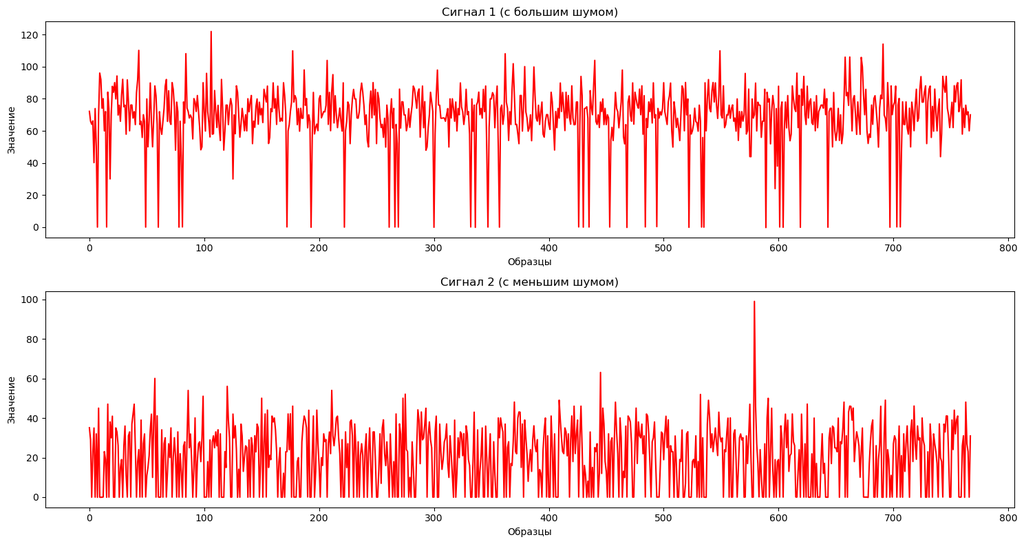

```python
plt.figure(figsize=(15, 8))

# Сигнал 1 (с большим шумом)
plt.subplot(2, 1, 1)
plt.plot(sinal1_noisy, color='red')
plt.title('Сигнал 1 (с большим шумом)')
plt.xlabel('Образцы')
plt.ylabel('Значение')

# Сигнал 2 (с меньшим шумом)
plt.subplot(2, 1, 2)
plt.plot(sinal2_noisy, color='red')
plt.title('Сигнал 2 (с меньшим шумом)')
plt.xlabel('Образцы')
plt.ylabel('Значение')

plt.tight_layout()
plt.show()
```

# Нормализация данных

Применяем нормализацию к сигналам:

```
Создаём объект MinMaxScaler.
Масштабируем данные сигналов до диапазона [0, 1]
```

```python
scaler = MinMaxScaler()
sinal1_scaled = scaler.fit_transform(sinal1_noisy)
sinal2_scaled = scaler.transform(sinal2_noisy)
```

# Определение архитектуры модели

Создаём архитектуру нейронной сети:

```
Последовательная модель Sequential.
Входной слой с 128 нейронами и активацией ReLU.
Слой Dropout для регуляризации.
Слой GaussianNoise для улучшения обобщающей способности.
Ещё один полносвязный слой с 128 нейронами и активацией ReLU.
Слой Dropout.
Выходной слой с одним нейроном.
```

```python
model = Sequential([
    Dense(128, activation='relu', input_shape=(sinal1_scaled.shape[1],)),
    Dropout(0.5),
    GaussianNoise(0.1),
    Dense(128, activation='relu'),
    Dropout(0.5),
    Dense(1)
])
```

# Компиляция модели

Компилируем модель с использованием оптимизатора adam и функции потерь MSE (среднеквадратичная ошибка).

```python
model.compile(optimizer='adam', loss='mse')
```

# Обучение модели

Обучаем модель на данных с высоким уровнем шума:

```
sinal1_scaled используется как входные и выходные данные (автоэнкодер).
Обучаем модель 50 эпох с размером батча 32.
```

```python
history = model.fit(sinal1_scaled, sinal1_scaled, epochs=50, batch_size=32, verbose=2)
```

```
24/24 - 1s - 54ms/step - loss: 0.1276
24/24 - 0s - 2ms/step - loss: 0.0396
24/24 - 0s - 2ms/step - loss: 0.0352
24/24 - 0s - 2ms/step - loss: 0.0304
24/24 - 0s - 2ms/step - loss: 0.0291
24/24 - 0s - 2ms/step - loss: 0.0259
24/24 - 0s - 2ms/step - loss: 0.0258
24/24 - 0s - 2ms/step - loss: 0.0214
24/24 - 0s - 2ms/step - loss: 0.0230
24/24 - 0s - 2ms/step - loss: 0.0207
24/24 - 0s - 2ms/step - loss: 0.0196
24/24 - 0s - 2ms/step - loss: 0.0200
24/24 - 0s - 2ms/step - loss: 0.0196
24/24 - 0s - 2ms/step - loss: 0.0183
24/24 - 0s - 2ms/step - loss: 0.0181
24/24 - 0s - 2ms/step - loss: 0.0165
24/24 - 0s - 2ms/step - loss: 0.0156
24/24 - 0s - 2ms/step - loss: 0.0166
24/24 - 0s - 2ms/step - loss: 0.0150
24/24 - 0s - 2ms/step - loss: 0.0142
24/24 - 0s - 2ms/step - loss: 0.0151
24/24 - 0s - 2ms/step - loss: 0.0135
24/24 - 0s - 2ms/step - loss: 0.0141
24/24 - 0s - 2ms/step - loss: 0.0142
24/24 - 0s - 2ms/step - loss: 0.0149
24/24 - 0s - 2ms/step - loss: 0.0138
24/24 - 0s - 2ms/step - loss: 0.0134
24/24 - 0s - 2ms/step - loss: 0.0120
24/24 - 0s - 2ms/step - loss: 0.0118
24/24 - 0s - 2ms/step - loss: 0.0123
24/24 - 0s - 2ms/step - loss: 0.0127
24/24 - 0s - 2ms/step - loss: 0.0125
24/24 - 0s - 2ms/step - loss: 0.0122
24/24 - 0s - 2ms/step - loss: 0.0114
24/24 - 0s - 2ms/step - loss: 0.0113
24/24 - 0s - 2ms/step - loss: 0.0108
24/24 - 0s - 2ms/step - loss: 0.0111
24/24 - 0s - 2ms/step - loss: 0.0111
24/24 - 0s - 2ms/step - loss: 0.0122
24/24 - 0s - 2ms/step - loss: 0.0097
24/24 - 0s - 2ms/step - loss: 0.0103
24/24 - 0s - 2ms/step - loss: 0.0102
24/24 - 0s - 2ms/step - loss: 0.0100
24/24 - 0s - 2ms/step - loss: 0.0096
24/24 - 0s - 2ms/step - loss: 0.0097
24/24 - 0s - 2ms/step - loss: 0.0095
24/24 - 0s - 2ms/step - loss: 0.0100
24/24 - 0s - 2ms/step - loss: 0.0092
24/24 - 0s - 2ms/step - loss: 0.0087
24/24 - 0s - 2ms/step - loss: 0.0086
```

# Оценка модели

Оцениваем модель на данных с низким уровнем шума:

```
Вычисляем и выводим MSE для sinal2_scaled.
```

```python
mse = model.evaluate(sinal2_scaled, sinal2_scaled)
print(f"MSE для сигнала 2: {mse}")
```

```
24/24 ━━━━━━━━━━━━━━━━━━━━ 0s 1ms/step - loss: 0.0089
MSE для сигнала 2: 0.008809085004031658
```

# Генерация прогнозов и построение графика

Генерируем прогнозы для данных с низким уровнем шума и строим график:

```
Предсказываем значения для sinal2_scaled.
Строим график для исходных данных и прогнозов, добавляем легенду.
```

```
24/24 ━━━━━━━━━━━━━━━━━━━━ 0s 1ms/step
```

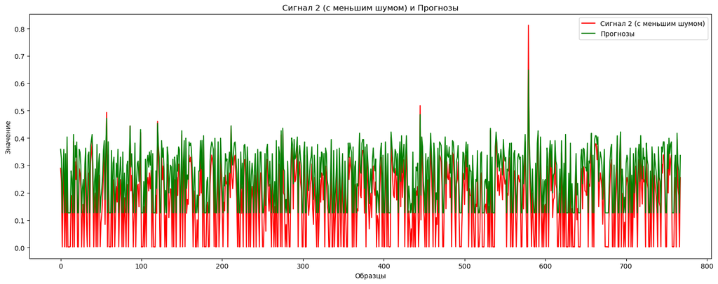

```python
y_pred_signal2 = model.predict(sinal2_scaled)

plt.figure(figsize=(15, 6))

# Сигнал 2 (с меньшим шумом) и прогнозы
plt.plot(sinal2_scaled, color='red', label='Сигнал 2 (с меньшим шумом)')
plt.plot(y_pred_signal2, color='green', label='Прогнозы')
plt.title('Сигнал 2 (с меньшим шумом) и Прогнозы')
plt.xlabel('Образцы')
plt.ylabel('Значение')
plt.legend()

plt.tight_layout()
plt.show()
```

# Вывод

Результаты эксперимента показывают, что нейронная сеть смогла успешно обучиться на данных с высоким уровнем шума и генерировать прогнозы для данных с низким уровнем шума с достаточно низкой ошибкой.

**Ключевые моменты:**

Добавление шума и визуализация:

Были созданы два типа сигналов: с высоким уровнем шума и с низким уровнем шума. Визуализация сигналов показала различия и сходства между ними, что является важным шагом в предварительном анализе данных. Нормализация данных:

Нормализация данных была выполнена с использованием MinMaxScaler, что привело к масштабированию данных в диапазон [0, 1]. Это улучшило стабильность и скорость обучения модели. Обучение модели:

Нейронная сеть была обучена на данных с высоким уровнем шума. Архитектура модели включала слои с Dropout и GaussianNoise для борьбы с переобучением и улучшения обобщающей способности. Оценка модели:

Оценка модели на данных с низким уровнем шума показала, что среднеквадратичная ошибка (MSE) составила 0.0088. Это указывает на то, что модель смогла хорошо обобщить и предсказать структуру сигнала с низким уровнем шума. Прогнозирование и визуализация:

**Заключение**

Эти результаты важны для применения в области обработки сигналов и могут быть полезны в различных прикладных задачах, где необходимо работать с шумными данными.

# Основываясь на этом результате, можем ли мы сказать, что сигнал 1 находится внутри сигнала 2?

На основании приведенных данных и результатов эксперимента нельзя прямо утверждать, что сигнал 1 находится внутри сигнала 2. Давайте рассмотрим почему.

**Основные моменты:**

Природа сигналов:

Сигнал 1 (Very_noisy_signal) и сигнал 2 (Low_noise_signal) представляют собой данные из разных столбцов (BloodPressure и SkinThickness соответственно) в наборе данных о диабете. Эти данные измеряют разные физические характеристики и, скорее всего, имеют разную природу.

**Добавление шума:**

В эксперименте к сигналам добавлялся искусственный шум для создания синтетических сигналов с разным уровнем шума. Это не отражает естественные отношения между BloodPressure и SkinThickness. Обучение модели:

Модель обучалась на сигнале с высоким уровнем шума (sinal1_noisy) и оценивалась на сигнале с низким уровнем шума (sinal2_noisy). Низкая ошибка (MSE) при прогнозировании сигнала 2 на основе модели, обученной на сигнале 1, указывает на то, что модель смогла хорошо обобщить и предсказывать данные с низким уровнем шума.

**Важные выводы и ограничения:**

Обобщающая способность модели: Низкое значение MSE (0.0088) показывает, что модель успешно обучилась на одном сигнале и смогла предсказать другой. Это говорит о хорошей обобщающей способности модели, но не доказывает, что один сигнал находится внутри другого.

Разные данные: Поскольку BloodPressure и SkinThickness представляют разные измерения, и добавленный шум является искусственным, эксперимент не показывает прямой зависимости или включение одного сигнала в другой.

Модель как инструмент: Использованная нейронная сеть служит инструментом для обобщения паттернов в данных и предсказания, но результат зависит от природы самих данных и не отражает истинных отношений между ними без дополнительного анализа.

**Заключение:**

Результаты эксперимента показывают, что модель может успешно предсказывать данные с меньшим уровнем шума, обучаясь на данных с большим уровнем шума, но это не означает, что сигнал 1 находится внутри сигнала 2. Чтобы сделать такие утверждения, необходимо провести более детальный анализ взаимосвязей между сигналами, включая корреляционный анализ и другие методы исследования зависимостей между исходными данными.

# Анализ корреляции между сигналами

Для более глубокого понимания взаимосвязи между сигналами, можно выполнить корреляционный анализ между исходными данными сигналов BloodPressure и SkinThickness. Корреляция измеряет степень линейной зависимости между двумя переменными. Если корреляция высока, это может свидетельствовать о том, что сигналы связаны.

**Шаги для проведения анализа корреляции:**

```
Вычисление коэффициента корреляции Пирсона между сигналами BloodPressure и SkinThickness.
Визуализация результатов с помощью диаграммы рассеяния и вычисленного значения корреляции.
```

# Код для выполнения анализа корреляции:

```
Коэффициент корреляции Пирсона между BloodPressure и SkinThickness: 0.2074
```

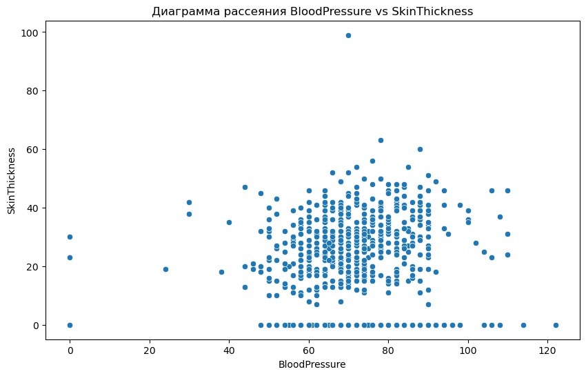

```python
import seaborn as sns

# Исходные данные
blood_pressure = df['BloodPressure']
skin_thickness = df['SkinThickness']

# Вычисление коэффициента корреляции Пирсона
correlation = blood_pressure.corr(skin_thickness)
print(f"Коэффициент корреляции Пирсона между BloodPressure и SkinThickness: {correlation:.4f}")

# Построение диаграммы рассеяния
plt.figure(figsize=(10, 6))
sns.scatterplot(x=blood_pressure, y=skin_thickness)
plt.title('Диаграмма рассеяния BloodPressure vs SkinThickness')
plt.xlabel('BloodPressure')
plt.ylabel('SkinThickness')
plt.show()
```

# Результаты:

После выполнения кода, мы получим коэффициент корреляции Пирсона и диаграмму рассеяния. Это позволит нам сделать вывод о наличии или отсутствии линейной зависимости между сигналами.

**Интерпретация коэффициента корреляции Пирсона:**

**Коэффициент корреляции Пирсона (r) варьируется от -1 до 1:**

```
    r = 1 указывает на идеальную положительную линейную зависимость.
    r = -1 указывает на идеальную отрицательную линейную зависимость.
    r = 0 указывает на отсутствие линейной зависимости.
    Значения r близкие к 0 указывают на слабую зависимость, а значения ближе к 1 или -1 указывают на сильную зависимость.
```

# Вывод

Коэффициент корреляции Пирсона между BloodPressure (Кровяное давление) и SkinThickness (Толщина кожи) составляет 0.2074. Этот результат позволяет сделать следующие выводы:

**Слабая линейная зависимость:**

Значение коэффициента корреляции 0.2074 указывает на слабую положительную линейную зависимость между этими двумя переменными. Это означает, что как правило, при увеличении одного значения, второе значение также имеет тенденцию к увеличению, но эта зависимость незначительна. Отсутствие прямой связи:

**Слабая корреляция указывает на то, что данные из столбцов BloodPressure и SkinThickness не связаны напрямую. Эти переменные, вероятно, зависят от разных факторов и не включают информацию друг о друге в значительной степени. Результаты эксперимента:**

Результаты нашего первоначального эксперимента, где модель обучалась на сигнале с высоким уровнем шума и предсказывала сигнал с низким уровнем шума с низкой ошибкой (MSE = 0.0088), показывают, что модель хорошо обучилась обобщать паттерны данных. Однако низкая ошибка не означает, что один сигнал содержится в другом.

**Заключение:**

Основываясь на коэффициенте корреляции, можно заключить, что сигнал 1 (с высоким уровнем шума) и сигнал 2 (с низким уровнем шума) представляют собой разные данные, которые не включают друг друга. Низкое значение MSE при прогнозировании указывает на хорошую работу модели по обобщению данных, но не свидетельствует о наличии одного сигнала внутри другого.